# C08 — Samoocena a wykonanie: korelacja, permutacja i prosta regresja

Zarządzanie informacją — ćwiczenie i zadanie Z08 — 2026/27

ID: [UZUPELNIJ_ID]

2026/27

# Początek pracy na ćwiczeniu C08

Otwórz swój projekt kursu w Posit Cloud albo RStudio na własnym komputerze; pakiet kursu `badaniaZI` jest w nim zainstalowany. Dwa polecenia z następnego bloku wpisujesz w konsoli RStudio, czyli w dolnym panelu ze znakiem `>`; w miejsce `TWOJE_ID` wpisz swoje ID, a w miejsce `Imię Nazwisko` — swoje imię i nazwisko. Dokument PDF zawiera dwa polecenia jako tekst instrukcji.

```r
library(badaniaZI)
rozpocznij_zajecia("C08", id_studenta = "TWOJE_ID", student = "Imię Nazwisko")
```

Sprawdź w komunikacie ID oraz imię i nazwisko. Przy pierwszym starcie funkcja tworzy folder `moje-badania` i zapisuje w nim oba dane; pliki pracy zachowują je także po zamknięciu projektu, a imię i nazwisko trafiają do nazwy oddawanego pliku.

Funkcja `rozpocznij_zajecia()` otwiera własny plik `zadanie.Rmd`, zapamiętuje katalog pracy i kopiuje do folderu `moje-badania/materialy` wersję HTML i PDF ćwiczenia oraz rubrykę zadania. Pracuj w otwartym pliku `zadanie.Rmd` do końca zajęć. Najpierw uruchom blok `przygotowanie`, a potem kolejne części LEARN i CHALLENGE. Przy problemie poproś prowadzącego o pomoc; plik pracy i własne ID pozostają bez zmian.

Pierwszy chunk, `przygotowanie`, wczytuje gotowy skrypt `analiza.R`. Skrypt tworzy zbiór S02 po trzech regułach ćwiczenia C02 (usunięcie identycznych duplikatów, kod 99 w pozycjach ankiety jako brak, czas spoza 0–120 minut jako brak) i liczy indeks sześciu pozycji według reguły 5/6 z ćwiczenia C04. Funkcja `analizuj_zwiazek()` liczy na kompletnych parach korelacje Pearsona i Spearmana, tasowanie, bootstrap par i regresję prostą ze stałym ziarnem losowania. Skrypt zawiera też dane portalu weryfikacji źródeł do części CHALLENGE, małe demonstracje oraz funkcje wyświetlające tabele i wykresy.

# Czy lepiej oceniany katalog to krótsze wyszukiwanie

Ćwiczenia C06 i C07 porównały grupy: indeks nowych był niższy o 0,44 punktu, a sukces wyniósł 60,8% u nowych i 70,3% u doświadczonych. Biblioteka pyta teraz, czy osoby lepiej oceniające użyteczność katalogu wykonują zadanie szybciej. Każda osoba ma dwie liczby: indeks z odpowiedzi na pozycje ankiety i czas z obserwacji zachowania.

Indeks S02 opisuje deklarowaną użyteczność katalogu: część pozycji dotyczy poczucia sprawności, część — cech interfejsu. Wniosek zachowuje treść pomiaru indeksu.

Czas łączy kilka mechanizmów: sprawne wykonanie, łatwe zadanie, szybkie porzucenie, trudność i dokładną kontrolę źródła. Czas odczytuje się obok sukcesu i protokołu zadania.

Dane kursu są syntetyczne, a miniatury — dydaktyczne; przedstawiają rachunek, kształt zależności i wpływ pojedynczej obserwacji.

## Przebieg spotkania

Przeznacz około 5 minut na odtworzenie pracy, 30 minut na pięć bloków LEARN, 50 minut na pięć zadań CHALLENGE i 5 minut na zapis oraz oddanie. W LEARN uruchamiasz gotowy kod i porównujesz wynik z podaną interpretacją. W CHALLENGE piszesz własne krótkie akapity pod wynikami, poza blokiem R. Gdy odczyt wyniku sprawia trudność, pytasz prowadzącego. Rozwinięcia po części obowiązkowej służą powtórce i pozostają poza oceną.

Bloki LEARN kończą się **wzorcem zapisu** — przykładowym zdaniem, które opisuje wynik według standardu APA (*Publication Manual of the American Psychological Association*, 7. wydanie, 2020): symbol statystyczny kursywą, stopnie swobody w nawiasie, przedział w nawiasie kwadratowym, przecinek jako separator dziesiętny. Zadania CHALLENGE stosują wzorce zapisu do scenariusza weryfikacji źródeł; projekt indywidualny rozpoczyna się na ćwiczeniu C09 (Warsztat projektu).

# LEARN 1: para wyników, liczebność i wykres

Jednostką jest osoba. Dla każdej osoby łączymy indeks $x$ i czas $y$. Korelacja opisuje sposób, w jaki wartości $x$ i $y$ występują razem u tych samych osób.

Tabela „Bilans ważnych pomiarów i par” podaje cztery liczebności: 148 osób po przygotowaniu, 147 z ważnym indeksem, 142 z ważnym czasem i 141 kompletnych par. Do wzoru korelacji wchodzą kompletne pary.

```r
widok <- bilans_do_odczytu()
print(widok)
```

**Bilans ważnych pomiarów i par**

| Zakres | N |
| --- | --- |
| Osoby po przygotowaniu | 148 |
| Ważny indeks | 147 |
| Ważny czas | 142 |
| Kompletne pary | 141 |

Osoba z jedną brakującą wartością wypada z analizy par, a pozostałe opisy kursu korzystają z jej ważnej wartości; różne N w C05, C07 i C08 wynikają z różnych zestawów wymaganych zmiennych. Usuwanie braków obejmuje całe wiersze, więc pary zachowują osoby.

Analiza kompletnych par jest jawną regułą o znanej konsekwencji: jeśli brak czasu częściej dotyczy osób przerywających zadanie, analizowane pary reprezentują osoby kończące zadanie. N par wynosi co najwyżej min(N x, N y) i spada przy brakach u różnych osób: minimum wynosi 142, a par jest 141.

**Wzorzec zapisu liczebności.**

> Analiza objęła 141 kompletnych par indeksu i czasu (*N* = 148 osób; ważny indeks u 147, ważny czas u 142 osób).

## Wykres jako pierwsza odpowiedź

Punkt odpowiada jednej osobie z dwiema ważnymi wartościami. Oś pozioma przedstawia indeks 1–5, pionowa — czas w minutach. Nakładające się punkty wynikają z ograniczonej liczby wartości indeksu.

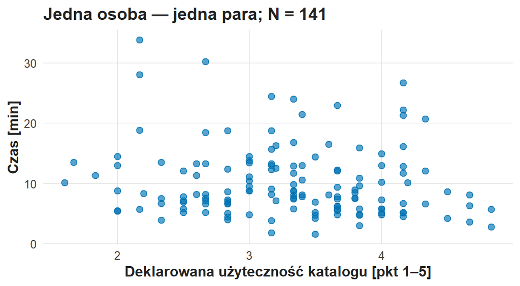

Indeks i czas: 141 kompletnych par S02. Oś pozioma: deklarowana użyteczność katalogu w punktach 1–5; oś pionowa: czas w minutach. Indeks leży od 1,6 do 4,8, a czas od 1,6 do 33,8 minuty; przy indeksie około 3 czasy rozciągają się od kilku do ponad 20 minut, a chmura ma lekki spadek.

```r
widok <- rozrzut_do_odczytu(wynik, "Deklarowana użyteczność katalogu [pkt 1–5]")
print(widok)
```

Czas osób o podobnym indeksie jest silnie zróżnicowany, więc prognoza indywidualna typu „osoba z oceną 4 będzie szukać pięć minut” ma duży błąd. Współczynnik dla połączonych danych może różnić się od zależności wewnątrz skupień (rozwinięcie „Połączenie grup i odwrócenie znaku”).

Wykres „Jak wygląda r = −0,13 obok silniejszych związków” zestawia standaryzowaną chmurę S02 z trzema chmurami syntetycznymi o tej samej liczbie par.

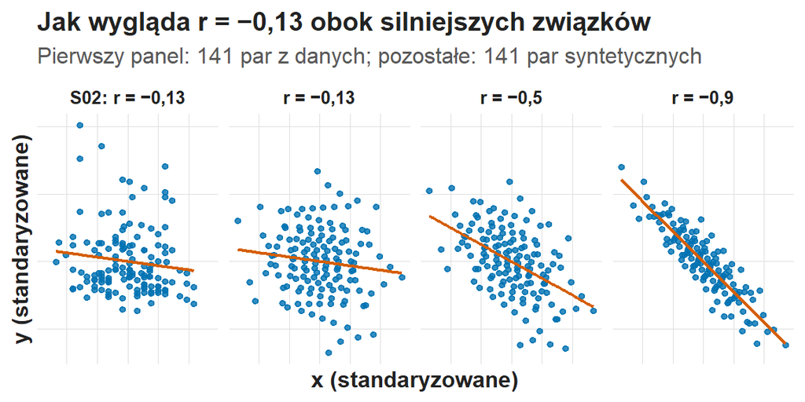

Jak wygląda r = −0,13 obok silniejszych związków. Cztery panele po 141 par, obie osie standaryzowane. Pierwszy panel: dane S02 (r = −0,13); drugi: chmura syntetyczna o r = −0,13; trzeci: r = −0,5; czwarty: r = −0,9. Chmura S02 i chmura o r = −0,13 są szerokie, z ledwie zauważalnym spadkiem prostej; przy r = −0,9 punkty tworzą wąskie pasmo wokół prostej.

```r
widok <- pokaz_wykres(wykres_galerii)
print(widok)
```

Przy r = −0,13 prosta ledwie opada, a punkty wypełniają cały prostokąt wykresu; przy r = −0,9 punkty układają się w wąskie pasmo.

# LEARN 2: Pearson, odchylenia i jednostka

$$r=\frac{\sum_{i=1}^n(x_i-\bar x)(y_i-\bar y)}
{\sqrt{\sum_{i=1}^n(x_i-\bar x)^2
\sum_{i=1}^n(y_i-\bar y)^2}}.$$

Licznik sumuje iloczyny odchyleń indeksu i czasu od ich średnich. Gdy wysokim $x$ częściej towarzyszą wysokie $y$, iloczyny są częściej dodatnie; gdy wysokim $x$ towarzyszą niskie $y$ — ujemne. Mianownik sprowadza wynik do zakresu [−1; 1]: $r$ jest liczbą bez jednostki i opisuje współzmienność w próbie.

Tabela „Odchylenia i iloczyny” rozpisuje miniaturę sześciu par z wykładu W05 (x = 1, 2, 2, 3, 4, 5; y = 15, 12, 14, 10, 9, 6).

```r
widok <- rachunek_korelacji()
print(widok)
```

**Odchylenia i iloczyny**

| Osoba | x | y | x − średnia | y − średnia | Iloczyn |
| --- | --- | --- | --- | --- | --- |
| a | 1 | 15 | -1,833 | 4 | -7,333 |
| b | 2 | 12 | -0,833 | 1 | -0,833 |
| c | 2 | 14 | -0,833 | 3 | -2,500 |
| d | 3 | 10 | 0,167 | -1 | -0,167 |
| e | 4 | 9 | 1,167 | -2 | -2,333 |
| f | 5 | 6 | 2,167 | -5 | -10,833 |

**Pearson i Spearman**

| r Pearsona | r Spearmana |
| --- | --- |
| −0,974 | −0,986 |

Miniatura jest celowo regularna: $r=-0{,}974$; w zbiorze S02 $r=-0{,}126$. Po zmianie minut na sekundy obie części wzoru związane z $y$ rosną w tej samej proporcji, więc $r$ pozostaje takie samo, a nachylenie regresji wyraża się wtedy w sekundach na punkt.

Odwrócenie kierunku jednej skali zmienia znak $r$. Zamiana osi pozostawia $r$ bez zmian; model regresji zależy od wyboru zmiennej objaśnianej.

## Spearman i remisy

Spearman zastępuje wyniki rangami i liczy korelację Pearsona na rangach:

$$r_S=r\big(R(x),\,R(y)\big),\qquad r_S=1-\frac{6\sum D_i^2}{n(n^2-1)}\ \text{bez remisów},$$

gdzie $R(\cdot)$ to średnie rangi, a $D_i$ — różnica rang osoby $i$. Spearman opisuje monotoniczność: czy większym wartościom jednej zmiennej towarzyszą na ogół większe albo na ogół mniejsze wartości drugiej. Zależność monotoniczna może mieć kształt krzywej.

Rangi opisują kolejność; zmianę w minutach opisuje nachylenie regresji. Miarę wybiera się przed obliczeniem p. W miniaturze $x=2$ występuje dwa razy, więc obie osoby otrzymują rangę 2,5 — średnią z miejsc 2 i 3. Remis oznacza równe wartości ze wspólną średnią rangą.

```r
widok <- rangi_do_odczytu()
print(widok)
```

**Średnie rangi przy remisach**

| Osoba | x | Ranga x | y | Ranga y |
| --- | --- | --- | --- | --- |
| a | 1 | 1,0 | 15 | 6 |
| b | 2 | 2,5 | 12 | 4 |
| c | 2 | 2,5 | 14 | 5 |
| d | 3 | 4,0 | 10 | 3 |
| e | 4 | 5,0 | 9 | 2 |
| f | 5 | 6,0 | 6 | 1 |

Wzór skrócony obowiązuje bez remisów; przy remisach funkcja liczy korelację Pearsona na średnich rangach. Ograniczona skala indeksu daje remisy także w S02, więc p Spearmana pochodzi z ustawienia `exact = FALSE` — z przybliżenia, bo remisy wykluczają dokładne wyliczenie. Przedział Spearmana pochodzi z bootstrapu par.

Każda miara opisuje jeden typ zależności: Pearson — liniową współzmienność wartości, Spearman — monotoniczną współzmienność rang. Kształt, niezależność osób i treść konstruktu ocenia się na podstawie wykresu, projektu i narzędzia (rozwinięcie „Trzy kształty, trzy odczyty”).

**Wzorzec zapisu kierunku i siły.**

> Wyższy indeks współwystępował ze słabo krótszym czasem: *r* = −0,13 dla wartości i *r*<sub>S</sub> = −0,14 dla rang.

# LEARN 3: tor klasyczny, przedział i dwa losowania

Symbole analizy związku

| Symbol | Odczyt |
| --- | --- |
| $n$ | Liczba kompletnych par osób |
| $r$, $r_S$ | Współczynnik Pearsona i rangowy Spearmana w próbie |
| $\rho_P$, $\rho_S$ | Odpowiednie parametry w modelu populacji |
| $t$, $S$ | Statystyki testowe Pearsona i Spearmana |
| df | Stopnie swobody, gdy procedura je podaje |
| $p$, $p_{\mathrm{perm}}$ | Skrajność w określonym modelu odniesienia |
| CI | Przedział konkretnego współczynnika |
| $B$, $k$ | Liczba losowań i liczba wyników co najmniej tak skrajnych |

Dla Pearsona test $H_0:\rho_P=0$ ma postać:

$$t=r\sqrt{\frac{n-2}{1-r^2}},\qquad df=n-2:\qquad t=-0{,}126\sqrt{\frac{139}{1-0{,}016}}=-1{,}498 .$$

Parametr $\rho_P$ odróżnia się od próbnego $r$. Przy niezależnych parach z dwuwymiarowego rozkładu normalnego (wykład W05) statystyka ma przy $H_0$ rozkład t; poza modelem dwuwymiarowego rozkładu normalnego test ma charakter przybliżony, a jakość przybliżenia maleje w małych i nietypowych próbach.

Tabela „Klasyczny odczyt; p Spearmana przybliżone” podaje: Pearson — $r=-0{,}126$, $t=-1{,}498$, df = 139, p = 0,1363; Spearman — $r_S=-0{,}136$, $S=530\,680$, p = 0,1080. Wynik Spearmana ma statystykę S bez df, a wielkość S zależy od N; siłę związku opisuje $r_S$.

```r
widok <- korelacja_do_odczytu(wynik)
print(widok)
```

**Klasyczny odczyt; p Spearmana przybliżone**

| Miara | N | Współczynnik | Statystyka | Symbol | df | p |
| --- | --- | --- | --- | --- | --- | --- |
| Pearson | 141 | −0,126 | −1,498 | t | 139 | 0,1363 |
| Spearman | 141 | −0,136 | 530679,767 | S | — | 0,1080 |

Wartość p = 0,108 opisuje skrajność wyniku przy $H_0$; zakres wartości parametru opisuje przedział.

## Przedział dla współczynnika

Przedział Pearsona z funkcji `cor.test` korzysta z transformacji Fishera:

$$z=\tfrac12\ln\frac{1+r}{1-r},\qquad z\pm1{,}96\cdot\frac{1}{\sqrt{n-3}},\qquad r=\frac{e^{2z}-1}{e^{2z}+1},$$

czyli $z=-0{,}127$, $1{,}96/\sqrt{138}=0{,}167$, a po powrocie na skalę $r$ — przedział [−0,285; 0,040]. Percentylowe przedziały bootstrapu całych par liczy funkcja dla obu miar.

Tabela „95% CI współczynnika” podaje: Pearson — Fisher [−0,285; 0,040], bootstrap [−0,292; 0,048]; Spearman — bootstrap [−0,306; 0,034]. Wszystkie trzy przedziały obejmują zero i wartości do około −0,3.

```r
widok <- przedzialy_korelacji(wynik)
print(widok)
```

**95% CI współczynnika**

| Metoda | Dolna granica | Górna granica |
| --- | --- | --- |
| Pearson: transformacja Fishera | −0,285 | 0,040 |
| Pearson: bootstrap par | −0,292 | 0,048 |
| Spearman: bootstrap par | −0,306 | 0,034 |

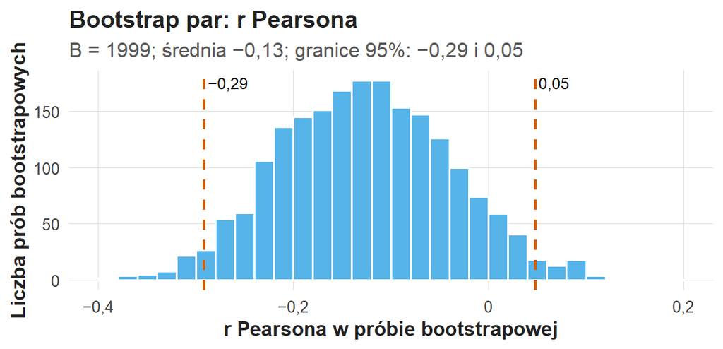

Bootstrap par: r Pearsona. Histogram 1999 współczynników z prób bootstrapowych, przedziały po 0,02. Oś pozioma: r Pearsona; oś pionowa: liczba prób. Rozkład ma środek przy −0,13; linie przerywane przy −0,29 i 0,05 wyznaczają percentylowy przedział 95%.

```r
print(pokaz_wykres(wykres_boot_pearson))
```

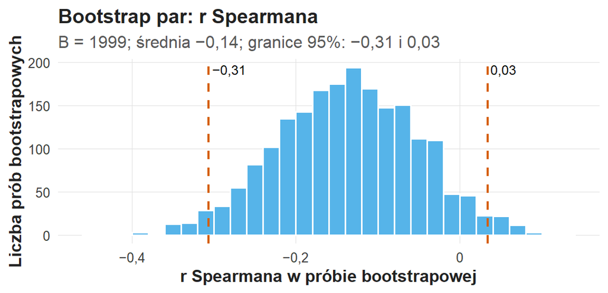

```r
print(pokaz_wykres(wykres_boot_spearman))
```

Przedział [−0,306; 0,034] obejmuje brak związku i umiarkowany związek ujemny. Poziom 95% jest długookresową własnością procedury przy jej założeniach. Bootstrap losował $B=1999$ prób tej samej liczebności ze zwracaniem; wszystkie repliki miały zmienność $x$ i $y$, więc wszystkie współczynniki są określone.

## Permutacja zmienia parowanie pod hipotezą zerową

W modelu niezależności i wymienialności $x$ pozostaje na miejscu, a wartości $y$ są losowo przestawiane między osobami. Oceny i czasy pozostają te same; zmienia się ich parowanie. Tabela „Jedno tasowanie czasów między osobami” przedstawia jedno przestawienie: osoba a otrzymuje czas 14 minut.

```r
widok <- pokaz_tabele(mini_losowanie, "Jedno tasowanie czasów między osobami", 0L)
print(widok)
```

**Jedno tasowanie czasów między osobami**

| Osoba | x | y | y po tasowaniu |
| --- | --- | --- | --- |
| a | 1 | 15 | 14 |
| b | 2 | 12 | 6 |
| c | 2 | 14 | 15 |
| d | 3 | 10 | 9 |
| e | 4 | 9 | 12 |
| f | 5 | 6 | 10 |

Dla każdej permutacji funkcja liczy wybrany współczynnik; dwustronna skrajność oznacza $|r^*|\geq|r_{\mathrm{obs}}|$:

$$p_{\mathrm{perm}}=\frac{k+1}{B+1},\qquad k=\#\{b:\ |r^*_b|\geq|r_{\mathrm{obs}}|\}.$$

Moduł obejmuje silną zależność dodatnią i ujemną. Najniższe możliwe p przy $B=1999$ wynosi 0,0005.

Tabela „Tasowanie y: dwustronne p Monte Carlo” podaje: Pearson — $k=260$, $p_{\mathrm{perm}}=261/2000=0{,}1305$; Spearman — $k=216$, $p_{\mathrm{perm}}=217/2000=0{,}1085$.

```r
widok <- losowanie_korelacji(wynik)
print(widok)
```

**Tasowanie y: dwustronne p Monte Carlo**

| Miara | Współczynnik | k | B | p_perm |
| --- | --- | --- | --- | --- |
| Pearson | −0,126 | 260 | 1999 | 0,1305 |
| Spearman | −0,136 | 216 | 1999 | 0,1085 |

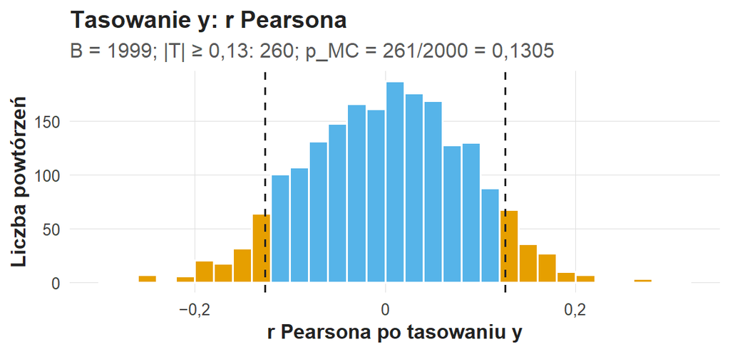

```r
print(pokaz_wykres(wykres_zerowy_pearson))
```

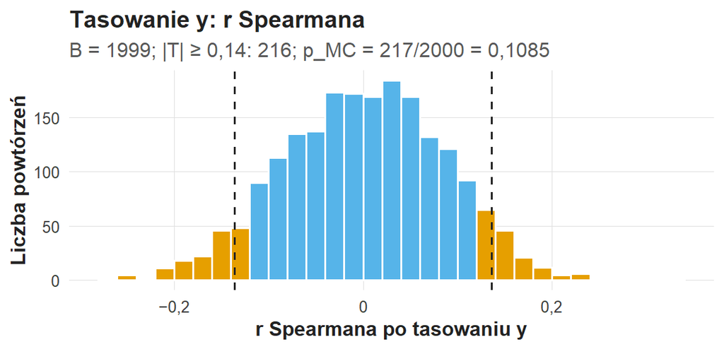

```r
print(pokaz_wykres(wykres_zerowy_spearman))
```

W S02 p klasyczne i permutacyjne są zbliżone: 0,136 i 0,131 dla Pearsona, 0,108 i 0,109 dla Spearmana. Permutacja zakłada wymienialność par; reprezentatywność i struktura pomiarów wynikają z projektu. Test permutacyjny sprawdza niezależność, test Pearsona — zerową korelację liniową; hipotezy są równoważne przy rozkładzie normalnym dwóch zmiennych.

## Co zachowuje bootstrap par

Próba bootstrapowa powstaje przez wybór całych wierszy ze zwracaniem. Tabela „Jedna replika: całe pary ze zwracaniem” ma osobę b dwukrotnie, osobę d dwukrotnie, a osoby c i e poza próbą; każdy $x$ pozostaje z własnym $y$.

```r
widok <- pokaz_tabele(mini_boot, "Jedna replika: całe pary ze zwracaniem", 0L)
print(widok)
```

**Jedna replika: całe pary ze zwracaniem**

| Osoba | x | y |
| --- | --- | --- |
| b | 2 | 12 |
| b | 2 | 12 |
| f | 5 | 6 |
| a | 1 | 15 |
| d | 3 | 10 |
| d | 3 | 10 |

Permutacja zmienia parowanie przy niezależności i wymienialności, aby odtworzyć rozkład zerowy. Bootstrap zachowuje pary i losuje osoby ze zwracaniem, aby przybliżyć niepewność współczynnika. Przy kilku zadaniach jednej osoby jednostką losowania jest osoba.

**Wzorzec zapisu korelacji (APA).**

> Indeks deklarowanej użyteczności słabo i ujemnie współwystępował z czasem wyszukiwania, *r*(139) = −0,13, *p* = 0,136, 95% CI [−0,29; 0,04]. Korelacja rang wyniosła *r*<sub>S</sub> = −0,14, *p* = 0,108, bootstrapowy 95% CI [−0,31; 0,03]; test permutacyjny (*B* = 1999) dał *p*<sub>perm</sub> = 0,109.

# LEARN 4: regresja dodaje jednostkę i kierunek przewidywania

Korelacja jest symetryczna, a w modelu wybiera się zmienną objaśnianą. Zmienną objaśnianą jest czas $y$, a predyktorem — indeks $x$:

$$Y_i=\beta_0+\beta_1x_i+\varepsilon_i,
\qquad \widehat y_i=b_0+b_1x_i .$$

Parametry $\beta_0,\beta_1$ należą do modelu populacji, a $b_0,b_1$ są oszacowaniami. Składnik $\varepsilon_i$ to odchylenie wyniku osoby od modelowej średniej, a reszta $e_i=y_i-\widehat y_i$ powstaje po dopasowaniu. Metoda najmniejszych kwadratów daje (wykład W05):

$$b_1=\frac{\sum(x_i-\bar x)(y_i-\bar y)}{\sum(x_i-\bar x)^2},\qquad b_0=\bar y-b_1\bar x=10{,}171+1{,}032\cdot3{,}289=13{,}567 ,$$

$$SE(b_1)=\frac{s_e}{\sqrt{\sum(x_i-\bar x)^2}}=\frac{5{,}827}{\sqrt{71{,}525}}=0{,}689,\qquad t=\frac{b_1}{SE(b_1)}=\frac{-1{,}032}{0{,}689}=-1{,}498 ,$$

gdzie $s_e$ to SD reszt. Statystyka t nachylenia równa się statystyce t korelacji Pearsona dla tych samych par.

Tabele „Współczynniki modelu: y w minutach, x w punktach” i „Testy parametrów równych zero” podają: nachylenie −1,032 minuty na punkt, SE 0,689, 95% CI [−2,395; 0,330], $t(139)=-1{,}498$, p = 0,1363; wyraz wolny 13,567.

```r
widok <- regresja_do_odczytu(wynik)
print(widok)
```

**Współczynniki modelu: y w minutach, x w punktach**

| Parametr | Estymata | SE | Dolna granica CI | Górna granica CI |
| --- | --- | --- | --- | --- |
| Wyraz wolny | 13,567 | 2,319 | 8,982 | 18,152 |
| Nachylenie | −1,032 | 0,689 | −2,395 | 0,330 |

**Testy parametrów równych zero**

| Parametr | t | df | p |
| --- | --- | --- | --- |
| Wyraz wolny | 5,850 | 139 | < 0,0001 |
| Nachylenie | −1,498 | 139 | 0,1363 |

Oszacowane równanie to $\widehat y=13{,}567-1{,}032x$: modelowy średni czas jest o 1,03 minuty krótszy przy indeksie wyższym o jeden punkt. Nachylenie porównuje osoby o różnych indeksach. Przedział obejmuje skrócenie o 2,4 minuty i wydłużenie o 0,3 minuty na punkt. Test Spearmana dotyczy rang i ma własne p.

Wyraz wolny wyznacza położenie prostej przy $x=0$, poza skalą 1–5. Po wycentrowaniu $x$ wokół 3 nowy wyraz wolny opisuje modelową średnią dla indeksu 3; nachylenie pozostaje bez zmian.

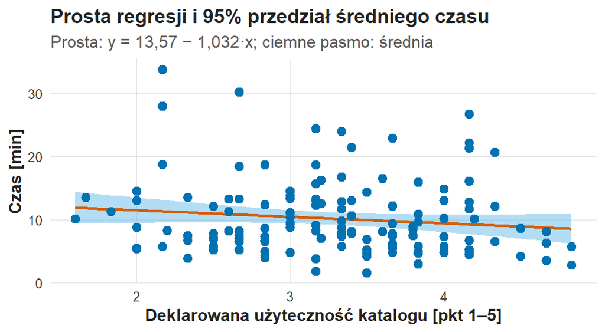

Prosta regresji i 95% przedział średniego czasu dla 141 par S02. Oś pozioma: indeks 1–5; oś pionowa: czas w minutach. Prosta spada o 1,03 minuty na punkt, od 11,9 minuty przy indeksie 1,6 do 8,6 minuty przy 4,8; pasmo średniej sięga od 9,4 do 14,4 minuty przy indeksie 1,6 i od 6,3 do 10,9 minuty przy 4,8, a punkty rozciągają się pionowo o ponad 30 minut.

```r
widok <- pokaz_wykres(wykres_regresji)
print(widok)
```

Pasmo przedstawia 95% przedział średniej warunkowej; indywidualne czasy leżą znacznie szerzej.

## R², SD reszt i granice dopasowania

$$R^2=1-\frac{SSE}{SST}
=1-\frac{\sum(y_i-\widehat y_i)^2}{\sum(y_i-\bar y)^2}=1-\frac{4719{,}9}{4796{,}1}=0{,}0159 .$$

SSE to suma kwadratów reszt, a SST — suma kwadratów odchyleń czasów od wspólnej średniej. $R^2$ porównuje błąd modelu z błędem przewidywania wszystkim tej samej średniej; w regresji prostej z wyrazem wolnym $R^2=r^2$. Tabela „Dopasowanie: R² bez jednostki; SD reszt w minutach” podaje $R^2=0{,}0159$ i SD reszt 5,83 minuty.

```r
widok <- dopasowanie_do_odczytu(wynik)
print(widok)
```

**Dopasowanie: R² bez jednostki; SD reszt w minutach**

| N | R² | SD reszt [min] | SSE | SST |
| --- | --- | --- | --- | --- |
| 141 | 0,0159 | 5,83 | 4719,9 | 4796,1 |

$R^2=0{,}0159$ oznacza, że prosta odtwarza 1,59% sumy kwadratów zmienności czasu w analizowanej próbie. Model opisuje średnią zależność; prognoza indywidualna ma rozrzut rzędu 5,8 minuty. Niskie $R^2$ opisuje udział zmienności czasu powiązany z indeksem; projekt może dodać informacje o zadaniu, doświadczeniu, dostępie i strategii.

Wysokie $R^2$ może wynikać z punktu wpływowego, wspólnego błędu pomiaru albo zależności nieliniowej, więc diagnostyka wraca do wykresów i protokołu.

**Wzorzec zapisu regresji (APA).**

> Indeks słabo przewidywał czas wyszukiwania: *b* = −1,03 min/pkt, *SE* = 0,69, *t*(139) = −1,50, *p* = 0,136, 95% CI [−2,39; 0,33]; *R*<sup>2</sup> = 0,016.

## Diagnostyka jako pytania do modelu

Reszta opisuje odległość osoby od prostej: dodatnia oznacza czas dłuższy od przewidywanego, ujemna — krótszy. Wykres „Reszty wobec przewidywanego czasu” ma na osi poziomej wartości przewidywane, na pionowej — reszty; linia przerywana oznacza zero.

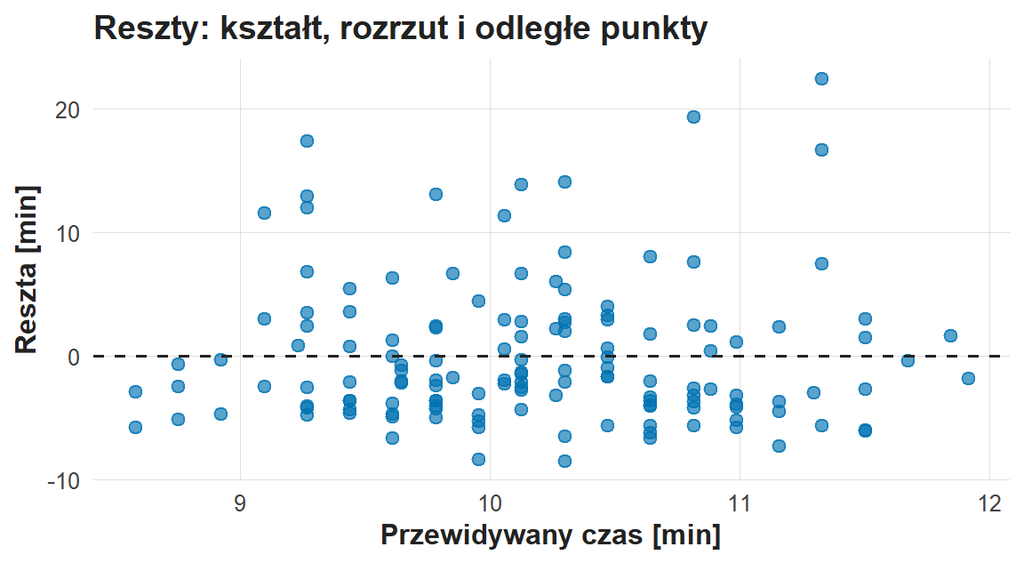

Reszty wobec przewidywanego czasu dla 141 par S02. Oś pozioma: przewidywany czas od 8,6 do 11,9 minuty; oś pionowa: reszta w minutach. Reszty leżą od −8,5 do 22,5 minuty; cztery reszty powyżej 15 minut tworzą prawy ogon, a rozrzut jest podobny w całym zakresie przewidywań.

```r
widok <- diagnostyka_do_odczytu(wynik)
print(widok)
```

Klasyczny model zakłada liniową postać średniej, niezależność błędów i stałą wariancję; dokładne wnioskowanie t w małej próbie zakłada też normalny rozkład błędów. Założenie normalności dotyczy błędów modelu. Wykres „Rozkład reszt i krzywa normalna” zestawia reszty z krzywą o SD 5,83 minuty.

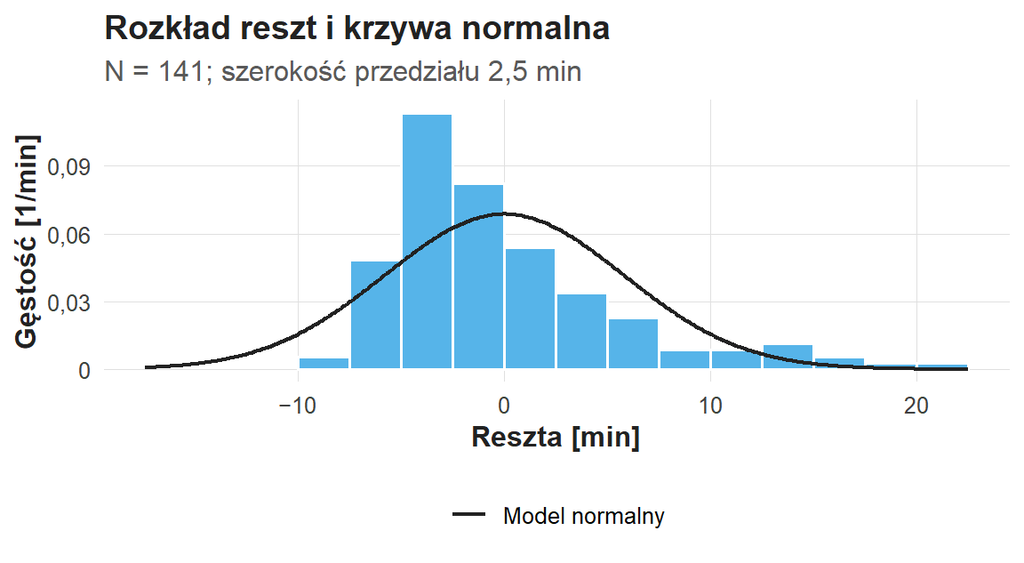

Rozkład reszt i krzywa normalna: histogram gęstości 141 reszt z przedziałami po 2,5 minuty. Oś pozioma: reszta w minutach; oś pionowa: gęstość. Najwyższe słupki leżą między −5 a 0 minut, prawy ogon sięga 22,5 minuty; krzywa normalna jest symetryczna i przypisuje wartościom powyżej 15 minut mniej pola, niż mają dane.

```r
widok <- pokaz_wykres(wykres_hist_reszt)
print(widok)
```

Reszty sięgają 22,5 minuty i ograniczają precyzję prognozy; odległy punkt wymaga sprawdzenia zapisu i protokołu.

# LEARN 5: średnia warunkowa i czas nowej osoby

Biblioteka pyta, jakiego przeciętnego czasu oczekiwać przy indeksie 3, a inna osoba — ile będzie szukać konkretny nowy użytkownik z indeksem 3. Dwa pytania mają dwie niepewności: średniej i pojedynczej osoby.

$$\widehat y_0\pm t_{0{,}975;\,n-2}\,s_e\sqrt{\frac1n+\frac{(x_0-\bar x)^2}{\sum(x_i-\bar x)^2}},\qquad
\widehat y_0\pm t_{0{,}975;\,n-2}\,s_e\sqrt{1+\frac1n+\frac{(x_0-\bar x)^2}{\sum(x_i-\bar x)^2}} .$$

Pierwszy wzór daje przedział średniej warunkowej, drugi — przedział predykcji dla nowej osoby; jedynka pod pierwiastkiem dodaje zmienność indywidualną. Przy $x_0=3$ połowy szerokości wynoszą 1,05 i 11,57 minuty.

Tabela „Dwa 95% przedziały: średnia i nowa osoba [min]” podaje przy $x=3$: przewidywany czas 10,47 minuty, przedział średniej [9,42; 11,52] i przedział nowej osoby [−1,10; 22,04].

```r
widok <- przewidywanie_czasu(wynik, x = 3)
print(widok)
```

**Dwa 95% przedziały: średnia i nowa osoba [min]**

| Przedmiot | Indeks x | Czas [min] | Dolna granica | Górna granica |
| --- | --- | --- | --- | --- |
| Średnia warunkowa | 3 | 10,47 | 9,42 | 11,52 |
| Nowa osoba | 3 | 10,47 | -1,10 | 22,04 |

Dolna granica −1,10 minuty sygnalizuje ograniczenie modelu normalnego dla dodatniego czasu. Zmiana granicy wymaga modelu dodatniego czasu, np. logarytmu czasu; eksponenta przewidywanego logarytmu daje średnią geometryczną (ćwiczenie C03), a skalę wybiera się na podstawie pytania.

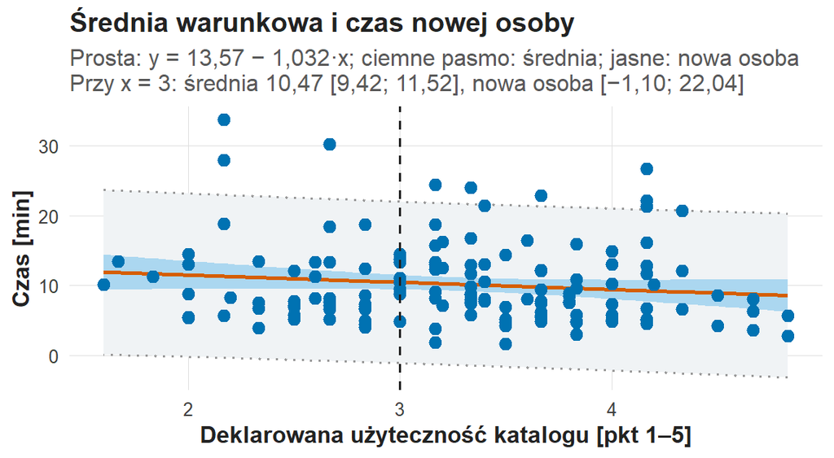

Średnia warunkowa i czas nowej osoby dla 141 par S02. Oś pozioma: indeks 1–5; oś pionowa: czas w minutach. Prosta y = 13,57 − 1,032x; ciemniejsze wąskie pasmo przedstawia 95% przedział średniej, jaśniejsze szerokie — 95% przedział predykcji. Przy x = 3 (linia przerywana) średnia wynosi 10,47 minuty z przedziałem [9,42; 11,52], a przedział nowej osoby [−1,10; 22,04].

```r
widok <- pokaz_wykres(wykres_predykcji)
print(widok)
```

Pasma rozszerzają się przy krańcach, bo dane zawierają mniej informacji o poziomach $x$ oddalonych od średniej 3,29. Ekstrapolacja poza skalę 1–5 jest pozbawiona sensu; prognoza dotyczy populacji i zadań podobnych do próby.

**Wzorzec zapisu prognozy (APA).**

> Przy indeksie 3 model przewidywał średni czas 10,47 min, 95% CI [9,42; 11,52]; przedział predykcji dla nowej osoby wyniósł [−1,10; 22,04] min, a ujemna granica wskazuje ograniczenie modelu normalnego dla czasu.

**Wzorzec pełnego akapitu wyniku.**

> W syntetycznej próbie 141 kompletnych par indeks deklarowanej użyteczności katalogu słabo i ujemnie współwystępował z czasem, *r*<sub>S</sub> = −0,14, *p* = 0,108, bootstrapowy 95% CI [−0,31; 0,03]; test permutacyjny (*B* = 1999) dał *p*<sub>perm</sub> = 0,109. Przedział obejmuje tendencję bliską zeru i wyraźniej ujemną. Model liniowy oszacował nachylenie *b* = −1,03 min/pkt, 95% CI [−2,39; 0,33], *R*<sup>2</sup> = 0,016, a przedział predykcji przy indeksie 3 sięgał od −1,10 do 22,04 min. Model opisuje związek obserwacyjny, a wniosek o skutku zmiany deklaracji wymaga projektu przyczynowego.

Współczynnik i przedział pochodzą z tego samego wiersza tabeli. Trafność samooceny wymaga zgodności poziomów (rozwinięcie „Samoocena: idealna korelacja i systematyczny błąd”); różnicę liczy się dla wyników w tej samej jednostce.

# CHALLENGE — samoocena weryfikacji źródeł i czas wykonania

W osobnym syntetycznym badaniu zarejestrowano 30 osób wykonujących to samo zadanie weryfikacji źródła w portalu informacyjnym. Przed zadaniem osoby oceniały na skali 1–5 cztery własne umiejętności: rozpoznanie autora, znalezienie daty publikacji, sprawdzenie podstawy twierdzenia i porównanie informacji z drugim źródłem; indeks samooceny jest średnią czterech odpowiedzi 1–5. Indeks opisuje deklarowaną sprawność weryfikacji źródeł. Obserwator rejestrował czas od rozpoczęcia do przesłania odpowiedzi, w minutach; zestaw zawiera czas bez oceny poprawności, więc krótszy czas opisuje tempo pracy. Badanie jest obserwacyjne.

Każde z pięciu zadań ma ten sam układ:

1. **Zadanie** — jedno zdanie z przedmiotem opisu.
2. **Blok R** — uruchom go; wynik zawiera wszystkie liczby potrzebne do odpowiedzi.
3. **Wskazówki** — gdzie w wyniku szukać informacji, jak ją nazwać i wzór zdania do uzupełnienia.
4. **W akapicie wymagane** — elementy, które sprawdza prowadzący.
5. **Twój akapit** — pole odpowiedzi w ramce: znacznik w nawiasie kwadratowym zastępujesz własnym tekstem, a linie komentarza nad nim i pod nim pozostawiasz bez zmian.

Akapit liczy 3–6 zdań zwykłego tekstu, bez kodu R. Liczby przepisujesz z wyniku bloku, z jednostką, symbolem i mianownikiem.

## CHALLENGE 1: Osoby, kompletne pary i wybór miary

**Zadanie:** opisz zmienne, liczebności i kształt chmury oraz wybierz główną miarę związku przed odczytem p.

```r
pary_zadania <- pary_portalu()
print(pary_zadania)
```

**Opis zmiennych**

| Zmienna | Znaczenie | Skala i źródło |
| --- | --- | --- |
| samoocena | Średnia czterech stwierdzeń o weryfikacji źródła | 1–5 pkt; deklaracja |
| czas | Od rozpoczęcia zadania do przesłania odpowiedzi | minuty; obserwacja |

**Bilans osób i par**

| Zakres | N |
| --- | --- |
| Zarejestrowane osoby | 30 |
| Ważna samoocena | 29 |
| Ważny czas | 29 |
| Kompletne pary | 28 |
| Brak przynajmniej jednej wartości | 2 |

**Osoby z brakiem**

| Osoba | Samoocena | Czas [min] |
| --- | --- | --- |
| w29 | NA | 12 |
| w30 | 3,5 | NA |

**Zakres wartości w kompletnych parach**

| Zmienna | Minimum | Mediana | Maksimum |
| --- | --- | --- | --- |
| samoocena [pkt] | 1,5 | 3 | 4,5 |
| czas [min] | 5,0 | 11 | 19,0 |

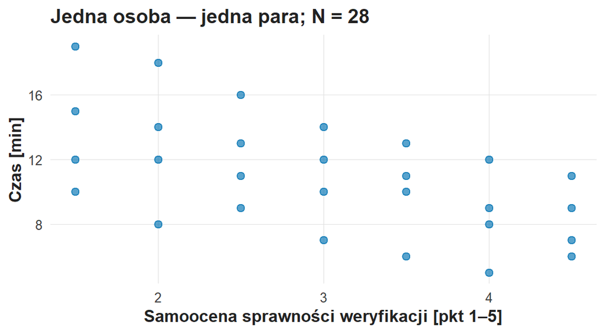

Samoocena i czas w portalu weryfikacji źródeł: jedna kropka to jedna osoba z kompletną parą. Oś pozioma: samoocena sprawności weryfikacji w punktach 1–5; oś pionowa: czas zadania w minutach.

Blok wyświetla tabele „Opis zmiennych”, „Bilans osób i par”, „Osoby z brakiem” i „Zakres wartości w kompletnych parach” oraz wykres par.

*Wskazówki:*

- Kompletna para to osoba z obiema wartościami. Tabela „Osoby z brakiem” wskazuje osoby, które wypadają z analizy, i brakującą u nich wartość.
- Liczba par wynika z braków u różnych osób: gdy braki dotyczą dwóch różnych osób, każda wypada osobno.
- Kierunek chmury: czy punkty po prawej stronie leżą na ogół niżej, czy wyżej od punktów po lewej? Rozrzut: jak szeroko rozciągają się czasy przy tej samej samoocenie?
- Pearson opisuje liniową współzmienność wartości; Spearman — monotoniczne uporządkowanie i pasuje do skali złożonej z odpowiedzi 1–5 z remisami. Wybór uzasadnia pytanie i wykres; wartość p pozostaje poza uzasadnieniem.
- Wzór zdania: „Analiza objęła [liczba] kompletnych par samooceny [skala] i czasu [jednostka] (*N* = [liczba] osób; braki: [osoby i wartości]). Chmura punktów [kierunek], a czasy przy podobnej samoocenie rozciągają się od [..] do [..] min. Główną miarą jest [Pearson/Spearman], ponieważ […]”.

*W akapicie wymagane:* (i) obie zmienne z jednostką i zakresem wniosku o pomiarze; (ii) liczby ważnych samoocen, czasów i kompletnych par z wyjaśnieniem różnicy; (iii) kierunek i rozrzut punktów; (iv) wybór Pearsona albo Spearmana z uzasadnieniem bez odwołania do p.

**Twój akapit S01.** Znacznik w nawiasie kwadratowym zastąp własnym tekstem.

[UZUPELNIJ_S01]

## CHALLENGE 2: Współczynnik i jego przedział

**Zadanie:** odczytaj współczynnik wybranej miary, jego test i przedział oraz skalę współczynnika.

Blok liczy Pearsona. Jeśli w CHALLENGE 1 wybierasz Spearmana, zmień w bloku słowo `"Pearson"` na `"Spearman"` i uruchom blok ponownie; to jedyna dozwolona zmiana kodu w zadaniu.

```r
korelacja <- wynik_korelacji_portalu(miara = "Pearson")
print(korelacja)
```

**Pearson: klasyczny test zerowej korelacji**

| Miara | N | Współczynnik | Statystyka | Symbol | df | p |
| --- | --- | --- | --- | --- | --- | --- |
| Pearson | 28 | −0,589 | −3,712 | t | 26 | 0,0010 |

**95% CI współczynnika**

| Metoda | Dolna granica | Górna granica |
| --- | --- | --- |
| Pearson: transformacja Fishera | −0,789 | −0,276 |
| Pearson: bootstrap par | −0,777 | −0,327 |

Blok wyświetla tabelę klasycznego testu wybranej miary (N, współczynnik, statystyka z symbolem, df, p) i tabelę „95% CI współczynnika” z nazwą metody.

*Wskazówki:*

- Pearson: statystyka $t=r\sqrt{(n-2)/(1-r^2)}$ ma $df=n-2$; podstaw $r$ i $n$ z tabeli i porównaj wynik z kolumną „Statystyka”.
- Spearman: statystyka S rośnie z N i ma df „—”; siłę związku opisuje współczynnik $r_S$.
- Współczynnik jest liczbą bez jednostki z przedziału [−1; 1]; przedział dotyczy współczynnika w populacji, a pojedyncza osoba ma swoją parę wyników.
- Wzorzec APA (Pearson): „*r*([df]) = [..], *p* = [..], 95% CI [[..]; [..]] (transformacja Fishera)”. Wzorzec APA (Spearman): „*r*<sub>S</sub> = [..], *S* = [..], *p* = [..], bootstrapowy 95% CI [[..]; [..]]”.

*W akapicie wymagane:* (i) nazwa parametru, N i współczynnik; (ii) statystyka z symbolem, df tylko dla Pearsona i p klasyczne; (iii) granice CI z nazwą metody; (iv) znak związku słowami; (v) skala współczynnika: liczba bez jednostki, różna od procentowego skrócenia czasu i od zakresu wyników osób.

**Twój akapit S02.** Znacznik w nawiasie kwadratowym zastąp własnym tekstem.

[UZUPELNIJ_S02]

## CHALLENGE 3: Dwa sposoby losowania

**Zadanie:** odczytaj test permutacyjny wybranej miary, porównaj go z p klasycznym i odróżnij tasowanie od bootstrapu.

```r
losowania <- losowania_portalu()
print(losowania)
```

**Tasowanie y: dwustronne p Monte Carlo**

| Miara | Współczynnik | k | B | p_perm |
| --- | --- | --- | --- | --- |
| Pearson | −0,589 | 2 | 1999 | 0,0015 |
| Spearman | −0,575 | 2 | 1999 | 0,0015 |

**Klasyczny odczyt tych samych par**

| Miara | N | Współczynnik | Statystyka | Symbol | df | p |
| --- | --- | --- | --- | --- | --- | --- |
| Pearson | 28 | −0,589 | −3,712 | t | 26 | 0,0010 |
| Spearman | 28 | −0,575 | 5753,909 | S | — | 0,0014 |

**Kontrola replik bootstrapu**

| Miara | Prawidłowe repliki | Repliki nieokreślone |
| --- | --- | --- |
| Pearson | 1999 | 0 |
| Spearman | 1999 | 0 |

Blok wyświetla tabele „Tasowanie y: dwustronne p Monte Carlo” (k, B i $p_{\mathrm{perm}}$ dla obu miar), „Klasyczny odczyt tych samych par” (p klasyczne obu miar) oraz „Kontrola replik bootstrapu”.

*Wskazówki:*

- Czytaj wiersz miary wybranej w CHALLENGE 1 w obu pierwszych tabelach.
- $p_{\mathrm{perm}}=(k+1)/(B+1)$: podstaw $k$ i $B$ z tabeli i sprawdź wynik.
- Tasowanie przestawia czasy między osobami, a samoocena każdej osoby zostaje na miejscu; skrajność liczy się w obu kierunkach, bo silny związek dodatni i ujemny przeczą niezależności.
- Bootstrap losuje całe pary ze zwracaniem i służy przedziałowi z CHALLENGE 2; B i liczba replik to liczby obliczeń, a uczestnikami są osoby z kompletnych par.
- Wzorzec APA: „Test permutacyjny (*B* = [..]) dał *p*<sub>perm</sub> = ([k] + 1)/([B] + 1) = [..], a test klasyczny *p* = [..]”.

*W akapicie wymagane:* (i) $k$, $B$ i $p_{\mathrm{perm}}$ z rachunkiem $(k+1)/(B+1)$; (ii) co przestawiano, co pozostało na miejscu i dlaczego skrajność jest dwustronna; (iii) porównanie z p klasycznym tej samej miary; (iv) różnica tasowania i bootstrapu całych par; (v) założenie niezależności i wymienialności.

**Twój akapit S03.** Znacznik w nawiasie kwadratowym zastąp własnym tekstem.

[UZUPELNIJ_S03]

## CHALLENGE 4: Model średniego czasu

**Zadanie:** zapisz równanie regresji, odczytaj nachylenie z niepewnością i $R^2$ oraz wskaż sygnał z wykresu reszt. Model obejmuje wszystkie kompletne pary, niezależnie od miary wybranej w CHALLENGE 1.

```r
model <- model_portalu()
print(model)
```

**Współczynniki modelu: y w minutach, x w punktach**

| Parametr | Estymata | SE | Dolna granica CI | Górna granica CI |
| --- | --- | --- | --- | --- |
| Wyraz wolny | 17,071 | 1,734 | 13,507 | 20,636 |
| Nachylenie | −2,036 | 0,548 | −3,163 | −0,908 |

**Testy parametrów równych zero**

| Parametr | t | df | p |
| --- | --- | --- | --- |
| Wyraz wolny | 9,844 | 26 | < 0,0001 |
| Nachylenie | −3,712 | 26 | 0,0010 |

**Dopasowanie modelu**

| N | R² | SD reszt [min] | SSE | SST |
| --- | --- | --- | --- | --- |
| 28 | 0,3464 | 2,90 | 218,9 | 335,0 |

**Trzy największe reszty**

| Osoba | Samoocena | Czas [min] | Przewidywany [min] | Reszta [min] |
| --- | --- | --- | --- | --- |
| w07 | 2,0 | 8 | 13,00 | -5,00 |
| w06 | 2,0 | 18 | 13,00 | 5,00 |
| w03 | 1,5 | 19 | 14,02 | 4,98 |

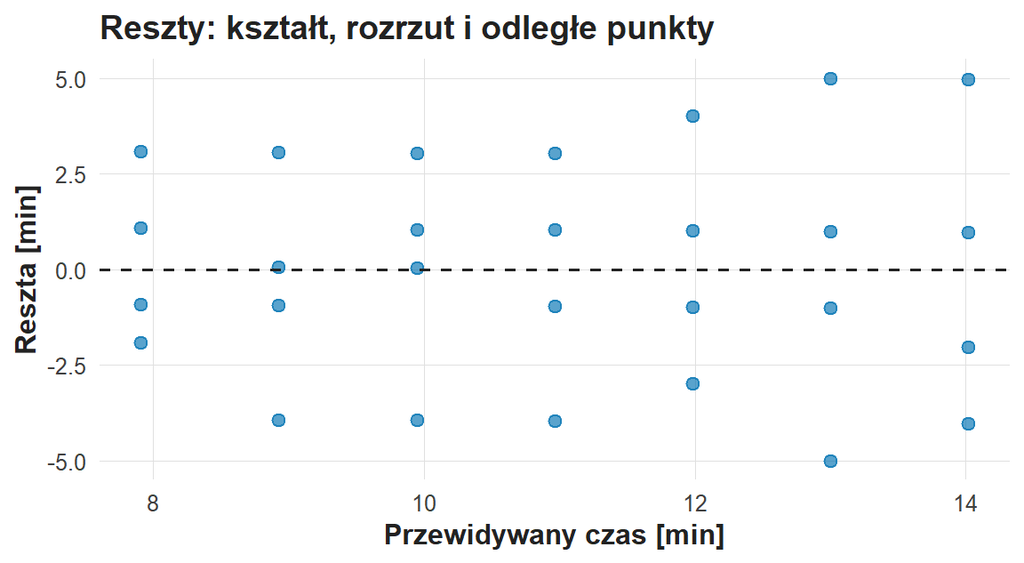

Reszty modelu portalu wobec przewidywanego czasu. Oś pozioma: przewidywany czas w minutach; oś pionowa: reszta w minutach; linia przerywana oznacza zero.

Blok wyświetla tabele „Współczynniki modelu: y w minutach, x w punktach”, „Testy parametrów równych zero”, „Dopasowanie modelu” i „Trzy największe reszty” oraz wykres reszt.

*Wskazówki:*

- Równanie ma postać $\widehat y=b_0+b_1x$: $b_0$ to wyraz wolny, $b_1$ — nachylenie z tabeli współczynników.
- Nachylenie to zmiana modelowego średniego czasu w minutach przy samoocenie wyższej o jeden punkt.
- Wyraz wolny opisuje $x=0$, a samoocena w danych leży od 1,5 do 4,5 punktu.
- $R^2$ to udział sumy kwadratów zmienności czasu odtworzony przez prostą w próbie portalu; SD reszt podaje typowy błąd prognozy w minutach.
- Sygnał z reszt: odległe punkty (tabela „Trzy największe reszty”), zmiana szerokości chmury albo łuk.
- Wzorzec APA: „$\widehat y$ = [b0] + ([b1])·x; *b* = [..] min/pkt, *SE* = [..], *t*([df]) = [..], *p* = [..], 95% CI [[..]; [..]]; *R*<sup>2</sup> = [..], SD reszt = [..] min”.

*W akapicie wymagane:* (i) równanie z jednostkami; (ii) nachylenie, SE, t, df, p i CI nachylenia; (iii) ograniczenie wyrazu wolnego przy $x=0$; (iv) $R^2$ jako udział zmienności w próbie; (v) jeden konkretny sygnał z reszt i jego konsekwencja dla modelu.

**Twój akapit S04.** Znacznik w nawiasie kwadratowym zastąp własnym tekstem.

[UZUPELNIJ_S04]

## CHALLENGE 5: Co wolno obiecać nowemu użytkownikowi

Zespół proponuje zdanie: „Osoba z samooceną 3 ukończy zadanie w około 10–12 minut, a podniesienie jej samooceny o jeden punkt skróci czas o nachylenie z tabeli”. Zdanie zawiera dwie obietnice: prognozę indywidualną i wniosek przyczynowy.

**Zadanie:** zastąp zdanie zespołu akapitem o średniej, prognozie dla osoby i granicy wniosku przyczynowego.

```r
przewidywanie <- prognoza_portalu(x = 3)
print(przewidywanie)
```

**Dwa 95% przedziały: średnia i nowa osoba [min]**

| Przedmiot | Indeks x | Czas [min] | Dolna granica | Górna granica |
| --- | --- | --- | --- | --- |
| Średnia warunkowa | 3 | 10,96 | 9,84 | 12,09 |
| Nowa osoba | 3 | 10,96 | 4,89 | 17,03 |

**Nachylenie modelu z 95% CI**

| Nachylenie [min/pkt] | Dolna granica CI | Górna granica CI |
| --- | --- | --- |
| −2,04 | −3,16 | −0,91 |

Blok wyświetla tabelę „Dwa 95% przedziały: średnia i nowa osoba [min]” dla samooceny 3 oraz tabelę „Nachylenie modelu z 95% CI”.

*Wskazówki:*

- Wiersz „Średnia warunkowa” dotyczy przeciętnego czasu osób z samooceną 3; wiersz „Nowa osoba” — czasu jednej nowej osoby. Porównaj szerokość obu przedziałów.
- Obietnica „10–12 minut” dotyczy jednej osoby, więc właściwym przedziałem jest przedział predykcji.
- Nachylenie opisuje różnicę między osobami o różnej samoocenie w badaniu obserwacyjnym; skutek podniesienia samooceny wymaga projektu z interwencją.
- Zestaw zawiera wyłącznie czas; ocena, czy krótszy czas oznacza lepszą weryfikację, wymaga oceny poprawności odpowiedzi.
- Wzorzec APA: „Przy samoocenie 3 model przewiduje średni czas [..] min, 95% CI [[..]; [..]]; czas nowej osoby mieści się w przedziale predykcji [[..]; [..]] min”.

*W akapicie wymagane:* (i) modelowa średnia z CI; (ii) przedział predykcji i wyjaśnienie różnicy szerokości; (iii) poprawiona obietnica indywidualna; (iv) poprawiona obietnica przyczynowa z kierunkiem i niepewnością nachylenia; (v) ograniczenie pomiaru i potrzebna obserwacja lub zmiana projektu.

**Twój akapit S05.** Znacznik w nawiasie kwadratowym zastąp własnym tekstem.

[UZUPELNIJ_S05]

# Zapis i oddanie

Sprawdź pięć własnych akapitów: CI i p dotyczą miary wybranej w CHALLENGE 1, regresja jest opisana na surowej skali minut i punktów, a znak, jednostka i kierunek osi są zgodne. Zapisz plik `zadanie.Rmd` w edytorze (Ctrl+S); funkcja oddania tworzy PDF z zapisanego pliku.

W konsoli wykonaj jedno polecenie. Funkcja oddania tworzy aktualny PDF, sprawdza kompletność, otwiera PDF do obejrzenia i po potwierdzeniu literą `t` wysyła go do folderu zadania prowadzącego na serwerze UJ (nc.uj.edu.pl). Nazwa pliku zawiera Twoje ID oraz nazwisko i imię.

```r
oddaj_zadanie("Z08")
```

Oddanie potwierdza komunikat z nazwą wysłanego pliku, folderem i czasem; plik `oddania.csv` w folderze `moje-badania` zapisuje także sumę SHA-256 wysłanego PDF. Po komunikacie błędu popraw wskazany problem, zapisz plik i ponownie wywołaj `oddaj_zadanie("Z08")`; nowa wersja trafia do folderu obok poprzedniej. Ocenę prowadzący przekazuje osobno.

Po potwierdzonym oddaniu możesz zamknąć projekt: Posit Cloud zachowuje folder `moje-badania` do kolejnych zajęć. Na komputerze współdzielonym wyloguj się z Posit Cloud w przeglądarce. Przy braku sieci PDF pozostaje w folderze zadania; wyślij go tym samym poleceniem po odzyskaniu połączenia, a gdy problem trwa, poproś prowadzącego o ustalenie sposobu dostarczenia pracy.

## Co jest oceniane

| Kryterium | Dowód w Twojej pracy | Odpowiedzi | Punkty |
| --- | --- | --- | --- |
| Z08.1 Dobór miary i odczyt wykresu kompletnych par | Zmienne, jednostki i zakres pomiaru; N ważnych wartości i kompletnych par; kierunek i rozrzut; wybór Pearsona albo Spearmana przed odczytem p | S01 | 3 |
| Z08.2 Współczynnik, niepewność i oba sposoby testowania | Parametr, N, współczynnik, statystyka, p i CI z metodą; k, B i $(k+1)/(B+1)$; tasowanie odróżnione od bootstrapu par; niezależność i wymienialność | S02, S03 | 2 |
| Z08.3 Równanie regresji, jednostki i diagnostyka | Równanie, nachylenie w minutach na punkt, SE, t, df, p i CI; wyraz wolny przy $x=0$; $R^2$ w próbie; sygnał z reszt | S04 | 3 |
| Z08.4 Średnia, przewidywanie osoby i granice przyczynowości | Średnia dla $x=3$ z CI i przedział predykcji; poprawione obietnice; ograniczenie pomiaru i potrzebna obserwacja | S05 | 2 |

Ocena dotyczy poprawności odczytu i uzasadnienia wniosku. Poziomy wykonania opisuje rubryka Z08: na stronie kursu w dokumencie `rubryki/Z08.html`, a w konsoli R po poleceniu `rubryka("Z08")`.

# Rozwinięcia do powtórki — poza rdzeniem spotkania

Rozwinięcia rozwijają granice skrótów liczbowych: kształt zależności, wpływ obserwacji, kalibrację samooceny i strukturę grup. Rozwinięcia służą powtórce i pozostają poza oceną.

## Trzy kształty, trzy odczyty

Serie są hipotetyczne: pierwsza maleje liniowo, druga maleje po krzywej, trzecia najpierw maleje, a potem rośnie.

```r
widok <- ksztalty_do_odczytu()
print(widok)
```

**Współczynniki trzech kształtów**

| Kształt | r Pearsona | r Spearmana |
| --- | --- | --- |
| Kształt U | 0,000 | 0 |
| Liniowy | -0,998 | -1 |
| Monotoniczny, zakrzywiony | -0,823 | -1 |

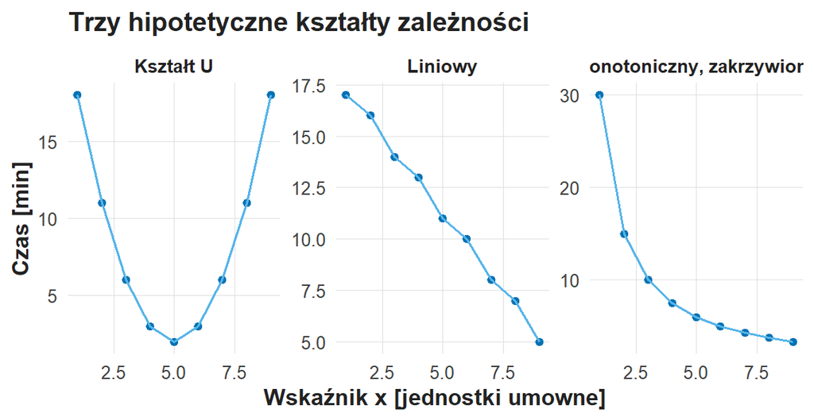

Trzy hipotetyczne kształty zależności, po dziewięć punktów. Oś pozioma: wskaźnik x; oś pionowa: czas w minutach, z osobną skalą w każdym panelu. Kształt U: r Pearsona 0 i r Spearmana 0 przy regularnym wzorcu; liniowy: r Pearsona −0,998 i r Spearmana −1; monotoniczny zakrzywiony: r Pearsona −0,823 i r Spearmana −1.

Tabela „Współczynniki trzech kształtów” podaje: liniowy — $r=-0{,}998$, $r_S=-1$; monotoniczny zakrzywiony — $r=-0{,}823$, $r_S=-1$; kształt U — $r=0$, $r_S=0$. Kształt U daje $r=0$ i $r_S=0$ przy regularnej zależności.

## Q–Q reszt, dźwignia i odległość Cooka

Wykres Q–Q zestawia kwantyle reszt z kwantylami rozkładu normalnego; odejście końców od prostej sygnalizuje ogony inne niż w rozkładzie normalnym.

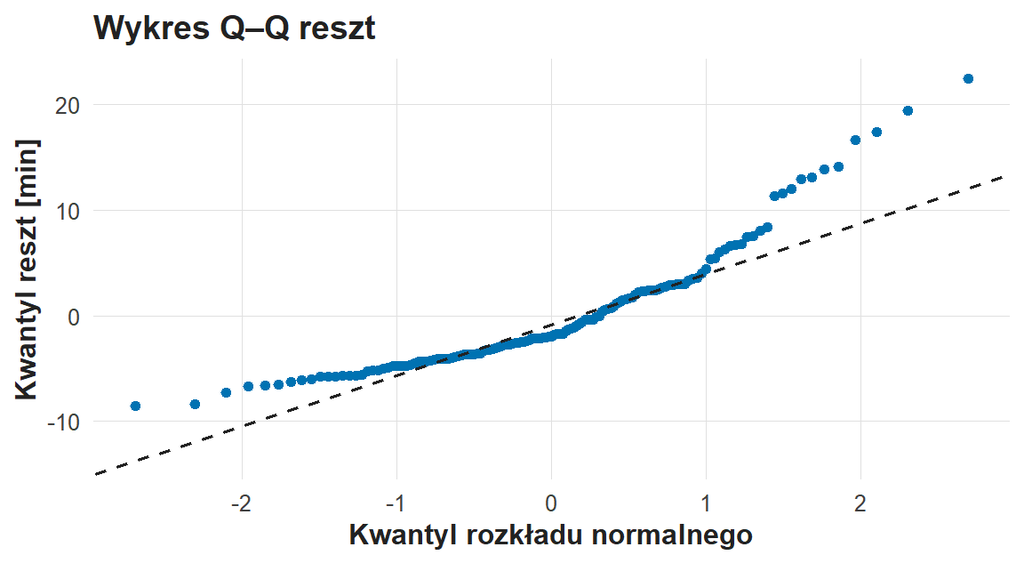

Wykres Q–Q reszt S02. Oś pozioma: kwantyl rozkładu normalnego; oś pionowa: kwantyl reszt w minutach. Punkty środkowe leżą blisko linii przerywanej, a prawy koniec wyraźnie nad nią: największe reszty są dłuższe, niż przewiduje rozkład normalny.

```r
widok <- pokaz_wykres(wykres_qq)
print(widok)
```

Diagnoza łączy wykres, założenia projektu i wrażliwość wniosku. Dźwignia $h_i$ opisuje nietypowe położenie $x$, reszta — nietypowe $y$ wobec prostej, a odległość Cooka łączy obie informacje:

$$h_i=\frac1n+\frac{(x_i-\bar x)^2}{\sum(x_j-\bar x)^2},\qquad D_i=\frac{e_i^2}{p\,s_e^2}\cdot\frac{h_i}{(1-h_i)^2},$$

gdzie $p=2$ to liczba parametrów modelu. Trzy miary wskazują rekordy do sprawdzenia; w S02 maksymalna dźwignia wynosi 0,047, a maksymalna odległość Cooka 0,19.

## Punkt wpływowy

W miniaturze dziewiąta osoba ma czas 30 minut. Czas 30 minut może być prawidłowym pomiarem; porównanie dwóch dopasowań jest analizą wrażliwości.

```r
widok <- wplyw_do_odczytu()
print(widok)
```

**Porównanie wrażliwości**

| Wariant | r | Nachylenie [min/jedn.] |
| --- | --- | --- |
| Wszystkie 9 osób | 0,706 | 2,233 |
| Pierwsze 8 osób | 0,950 | 0,774 |

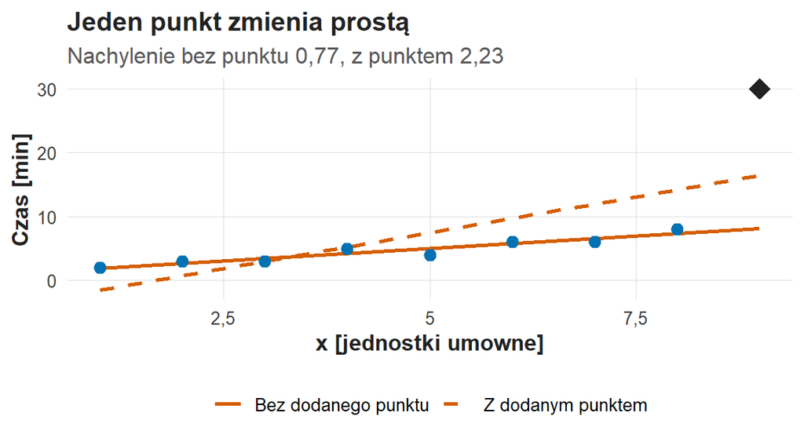

Jeden punkt zmienia prostą. Oś pozioma: x; oś pionowa: czas w minutach. Koła: osiem pierwotnych par; romb: dziewiąta osoba (x = 9, 30 minut). Linia ciągła: prosta bez dziewiątej osoby, nachylenie 0,77; linia przerywana: prosta z dziewiątą osobą, nachylenie 2,23.

Tabela „Porównanie wrażliwości” podaje: dziewięć osób — $r=0{,}706$, nachylenie 2,23; osiem osób — $r=0{,}950$, nachylenie 0,77. Dodatkowy punkt zwiększa nachylenie w jednostkach i jednocześnie osłabia liniową regularność. Raport opisuje sprawdzenie rekordu i obie wersje.

## Samoocena: idealna korelacja i systematyczny błąd

Pięć osób przewiduje swój procent poprawnych odpowiedzi w zadaniu weryfikacji źródeł, a potem wykonuje ten sam zestaw, więc deklarację i obserwację porównuje się w punktach procentowych. Kalibrację opisuje średni błąd (wykład W05):

$$\bar e=\frac1n\sum_i(\text{samoocena}_i-\text{wynik}_i)=20\ \text{pp},\qquad r=1 .$$

```r
widok <- kalibracja_do_odczytu()
print(widok)
```

**Samoocena i wynik na tej samej skali**

| Osoba | Wynik obserwowany [%] | Samoocena [%] | Błąd [pp] |
| --- | --- | --- | --- |
| a | 20 | 40 | 20 |
| b | 30 | 50 | 20 |
| c | 40 | 60 | 20 |
| d | 50 | 70 | 20 |
| e | 60 | 80 | 20 |

**Korelacja i średni błąd samooceny**

| r | Średni błąd [pp] |
| --- | --- |
| 1,000 | 20 |

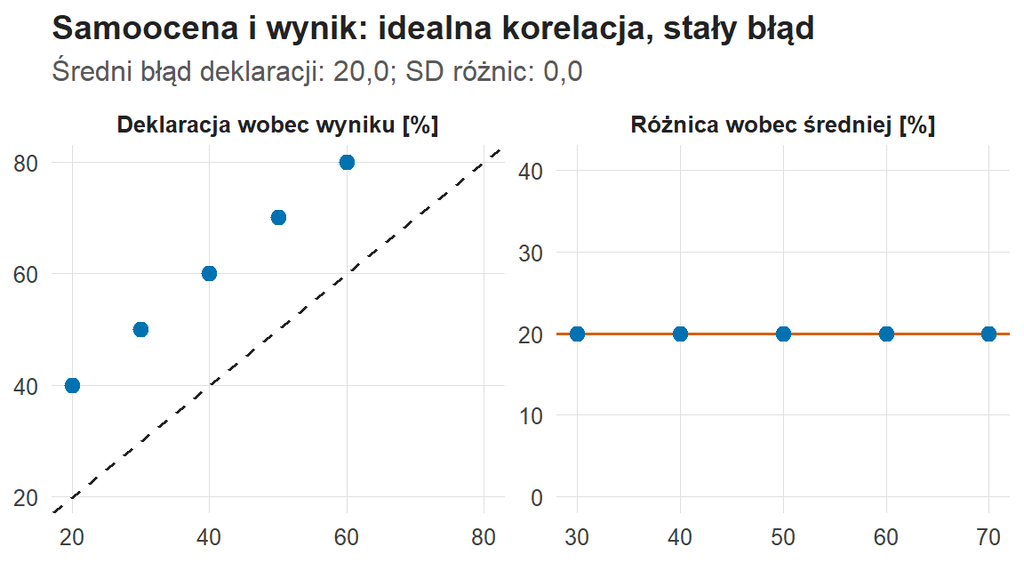

Samoocena i wynik: idealna korelacja, stały błąd. Lewy panel: samoocena wobec wyniku w procentach z linią zgodności y = x (przerywana); pięć punktów leży na prostej równoległej, 20 punktów procentowych nad linią. Prawy panel: różnica samoocena minus wynik wobec średniej obu pomiarów; wszystkie różnice wynoszą 20.

$r=1$ opisuje idealną zgodność kolejności, a średni błąd +20 punktów procentowych — systematyczne zawyżenie. Kalibracja deklaracji 80% wymaga wielu porównywalnych zdarzeń. Różnicę liczy się dla wyników w tej samej jednostce i o tym samym konstrukcie, więc indeks 1–5 i czas w minutach wymagają innego planu porównania.

## Połączenie grup i odwrócenie znaku

W hipotetycznym projekcie bardziej doświadczeni uczestnicy częściej otrzymują trudne zadania. W każdej grupie trudności większe doświadczenie wiąże się z krótszym czasem, a po połączeniu grup korelacja jest dodatnia.

```r
widok <- grupy_do_odczytu()
print(widok)
```

**Korelacja łączna i wewnątrz grup**

| Zakres | r |
| --- | --- |
| Razem | 0,513 |
| Łatwe zadanie | -1,000 |
| Trudne zadanie | -1,000 |

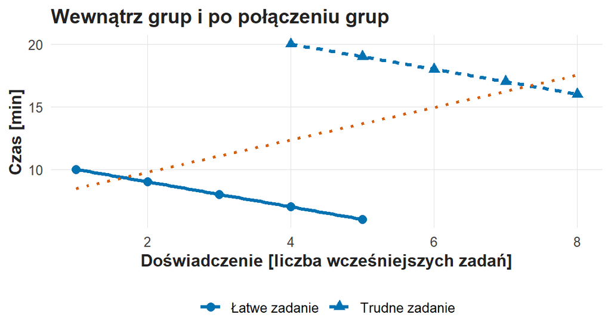

Wewnątrz grup i po połączeniu grup. Oś pozioma: doświadczenie w liczbie wcześniejszych zadań; oś pionowa: czas w minutach. Zadania łatwe: koła i linia ciągła, zadania trudne: trójkąty i linia przerywana; w każdej grupie punkty leżą na prostej malejącej, a grupa trudnych leży wyżej i dalej w prawo. Linia kropkowana dla wszystkich dziesięciu punktów rośnie.

Tabela „Korelacja łączna i wewnątrz grup” podaje $r=0{,}513$ dla wszystkich punktów i $r=-1$ w każdej grupie. Oba rachunki są poprawne i odpowiadają na różne pytania. Podział na grupy porządkuje strukturę danych; model prosty zawiera jeden predyktor, a słowo „wpływ” wymaga projektu kontrolującego wspólne przyczyny.

## Wynik 0/1 jako zmienna objaśniana

Korelacja Pearsona zmiennej liczbowej z kodem 0/1 zależy od kodowania sukcesu. Regresja liniowa wyniku 0/1 opisuje liniowe przybliżenie proporcji, z nachyleniem w jednostkach prawdopodobieństwa na punkt $x$; prognozy mogą wyjść poza [0; 1], a wariancja błędu zależy od $x$. Wynik binarny wymaga odrębnego planu, np. regresji logistycznej.

# Po spotkaniu

Zmiana minut na sekundy pozostawia $r$, p korelacji i $R^2$ bez zmian, a nachylenie i jego CI mnoży przez 60. Dodanie 20 punktów procentowych do każdej samooceny w badaniu kalibracji pozostawia korelację, a zwiększa systematyczny błąd. Siła zależności, naturalna jednostka i zgodność poziomów to trzy różne informacje.

Ćwiczenie C09 (Warsztat projektu) wykorzystuje to rozróżnienie przy planowaniu dwóch pytań projektu, a ćwiczenie C10 łączy wyniki w raport, w którym każdy wniosek ma własną podstawę i granicę.

Kontekst badań: Hargittai (2002), van Deursen, Helsper i Eynon (2016), DigComp 2.2 i ACRL. Procedury opisuje dokumentacja funkcji [cor.test](https://stat.ethz.ch/R-manual/R-devel/library/stats/html/cor.test.html) i [predict.lm](https://stat.ethz.ch/R-manual/R-devel/library/stats/html/predict.lm.html); resampling — Efron (1979), Winkler i współautorzy (2014), Phipson i Smyth (2010). Pełne opisy źródeł zawiera bibliografia na stronie kursu.